# Food Deserts Analysis

Team 1

2023-10-26

## Data Loading and Preprocessing

```r
# Loading data
data <- read.csv("food_access_research_atlas.csv")
```

## Question 4: Relationship between Poverty Rate and Food Deserts

### Analyzing Poverty Rate in Different Tracts

```r
# Assuming `data` is the dataframe you have
data %>%
  group_by(LILATracts_1And10) %>%
  summarise(mean_poverty_rate = mean(PovertyRate))
```

```
## # A tibble: 2 × 2
##   LILATracts_1And10 mean_poverty_rate
##               <int>             <dbl>
## 1                 0              15.1
## 2                 1              26.5
```

```r
data %>%
  group_by(LILATracts_1And20) %>%
  summarise(mean_poverty_rate = mean(PovertyRate))
```

```
## # A tibble: 2 × 2
##   LILATracts_1And20 mean_poverty_rate
##               <int>             <dbl>
## 1                 0              15.2
## 2                 1              27.1
```

```r
data %>%
  group_by(LowIncomeTracts) %>%
  summarise(mean_poverty_rate = mean(PovertyRate))
```

```
## # A tibble: 2 × 2
##   LowIncomeTracts mean_poverty_rate
##             <int>             <dbl>
## 1               0              8.63
## 2               1             27.4
```

```r
## Poverty rate is high in non low access areas
data %>%
  group_by(LA1and10) %>%
  summarise(mean_poverty_rate = mean(PovertyRate))
```

```
## # A tibble: 2 × 2
##   LA1and10 mean_poverty_rate
##      <int>             <dbl>
## 1        0              18.0
## 2        1              14.2
```

```r
data %>%
  group_by(LA1and20) %>%
  summarise(mean_poverty_rate = mean(PovertyRate))
```

```
## # A tibble: 2 × 2
##   LA1and20 mean_poverty_rate
##      <int>             <dbl>
## 1        0              17.8
## 2        1              14.1
```

The mean poverty rate is 26.5 for food deserts and for non-food deserts it is 15.1. So the Poverty rate in food deserts is 75% higher than non-food deserts. Poverty rate in Low access area is 14.2 whereas in non-low access area is 18.0.

### Count of Low Income tracts in Low access tracts

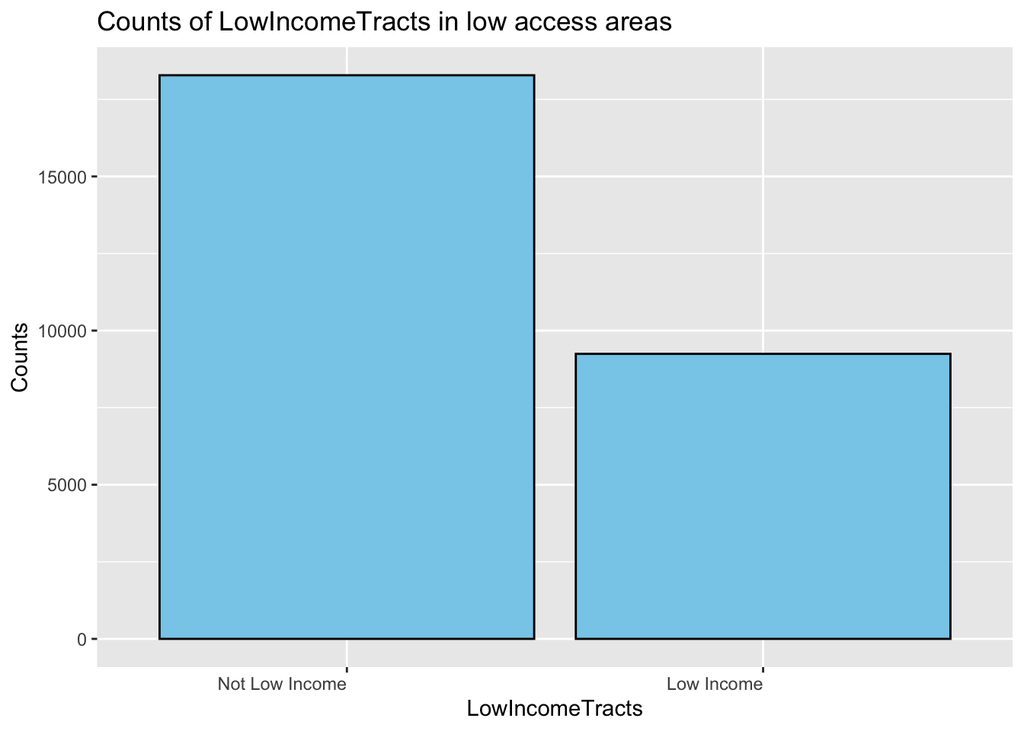

```r
# Filtering data for rows where LA1and10 is 1
filtered_data <- data[data$LA1and10 == 1, ]

# Calculating value counts for LowIncomeTracts
value_counts <- table(filtered_data$LowIncomeTracts)

# Converting to data frame for ggplot
value_counts_df <- as.data.frame(value_counts)
names(value_counts_df) <- c("LowIncomeTracts", "Counts")

# Creating custom labels
value_counts_df$Labels <- ifelse(value_counts_df$LowIncomeTracts == 0, "Not Low Income",
                                 ifelse(value_counts_df$LowIncomeTracts == 1, "Low Income", value_counts_df$LowIncomeTracts))

# Creating the bar plot
p <- ggplot(value_counts_df, aes(x = reorder(Labels, -Counts), y = Counts)) +
  geom_bar(stat = "identity", fill = "skyblue", color = "black") +
  labs(title = "Counts of LowIncomeTracts in low access areas", x = "LowIncomeTracts", y = "Counts") +
  theme(axis.text.x = element_text(angle = 0, hjust = 1))

# Showing the plot
print(p)
```

## Relationship between states and poverty rate

### Statewise average poverty rate

```r
#
# states_pov <- data %>%
#   group_by(State) %>%
#   summarise(avg_poverty_rate = mean(PovertyRate))
# #print(states_pov)


states_pov <- data %>%
  group_by(State) %>%
  summarise(avg_poverty_rate = mean(PovertyRate, na.rm = TRUE)) %>%
  arrange(desc(avg_poverty_rate))
print(states_pov)
```

```
## # A tibble: 51 × 2
##    State                avg_poverty_rate
##    <chr>                           <dbl>
##  1 Mississippi                      24.6
##  2 Louisiana                        21.6
##  3 Alabama                          21.2
##  4 New Mexico                       20.8
##  5 Georgia                          20.5
##  6 Arkansas                         20.4
##  7 Kentucky                         20.1
##  8 District of Columbia             19.7
##  9 West Virginia                    19.6
## 10 South Carolina                   19.6
## # ℹ 41 more rows
```

```r
print(sum(is.na(data$PovertyRate)))
```

```
## [1] 0
```

### Normalize poverty rate

```r
states_pov$norm_poverty_rate <- scale(states_pov$avg_poverty_rate)
print(states_pov)
```

```
## # A tibble: 51 × 3
##    State                avg_poverty_rate norm_poverty_rate[,1]
##    <chr>                           <dbl>                 <dbl>
##  1 Mississippi                      24.6                  2.52
##  2 Louisiana                        21.6                  1.65
##  3 Alabama                          21.2                  1.53
##  4 New Mexico                       20.8                  1.39
##  5 Georgia                          20.5                  1.32
##  6 Arkansas                         20.4                  1.27
##  7 Kentucky                         20.1                  1.21
##  8 District of Columbia             19.7                  1.09
##  9 West Virginia                    19.6                  1.06
## 10 South Carolina                   19.6                  1.05
## # ℹ 41 more rows
```

The poverty rate is normalised to find the correlation between poverty rate of states and food deserts

### Identify states with high poverty

```r
threshold <- quantile(states_pov$norm_poverty_rate, 0.85)
states_high_pov <- states_pov %>%
  filter(norm_poverty_rate > threshold)
print(states_high_pov)
```

```
## # A tibble: 8 × 3
##   State                avg_poverty_rate norm_poverty_rate[,1]
##   <chr>                           <dbl>                 <dbl>
## 1 Mississippi                      24.6                  2.52
## 2 Louisiana                        21.6                  1.65
## 3 Alabama                          21.2                  1.53
## 4 New Mexico                       20.8                  1.39
## 5 Georgia                          20.5                  1.32
## 6 Arkansas                         20.4                  1.27
## 7 Kentucky                         20.1                  1.21
## 8 District of Columbia             19.7                  1.09
```

To address the question whether states with high poverty rate also have high number of food deserts, we are filtering only the states above 85th percentile of poverty rate.

### Correlation between states and food deserts

```r
# Calculate statewise food desert count
states_food_deserts <- data %>%
  filter(LILATracts_1And10 == 1) %>%
  count(State)
#print(states_food_deserts)

# Normalize food desert counts
states_food_deserts$norm_count <- scale(states_food_deserts$n)

merged_data <- inner_join(states_high_pov, states_food_deserts, by = "State")
merged_data_all <- inner_join(states_pov, states_food_deserts, by = "State")
# Get correlation
# There is no correlation between poverty rates and food desert status
# The states with high poverty don't have high number of food deserts
#print(cor(merged_data$norm_poverty_rate, merged_data$norm_count, method = "pearson"))
#### Checking correlation of poverty rate and food desert status of all the states
#### There is very less correlation between povery rate and food deserts in all states
#print(cor(states_pov$norm_poverty_rate, states_food_deserts$norm_count, method = "pearson"))

#print(merged_data)
cor.test(merged_data$norm_poverty_rate, merged_data$norm_count, method="pearson")
```

```
##
##  Pearson's product-moment correlation
##
## data:  merged_data$norm_poverty_rate and merged_data$norm_count
## t = 0.532, df = 6, p-value = 0.61
## alternative hypothesis: true correlation is not equal to 0
## 95 percent confidence interval:
##  -0.57905  0.79761
## sample estimates:
##     cor
## 0.21222
```

```r
#cor.test(states_pov$norm_poverty_rate, states_food_deserts$norm_count, method="pearson")
cor.test(merged_data_all$norm_poverty_rate, merged_data_all$norm_count, method="pearson")
```

```
##
##  Pearson's product-moment correlation
##
## data:  merged_data_all$norm_poverty_rate and merged_data_all$norm_count
## t = 3.15, df = 49, p-value = 0.0028
## alternative hypothesis: true correlation is not equal to 0
## 95 percent confidence interval:
##  0.15139 0.61589
## sample estimates:
##     cor
## 0.40988
```

### Pearson Correlation:

#### High Poverty States and food desert count

**Null hypothesis**: There is no correlation between High poverty rate states with count of their food desert **Alternate hypothesis** : There is Correlation between High poverty rate states with count of their food desert. At level of significance alpha set at = 0.05, as The p-value 0.6 is higher than the 0.05, we fail to reject the null hypothesis. The pearson correlation results tell us “There is no correlation between High poverty rate states with count of their food desert”

#### Poverty rate of All States and food desert count

**Null hypothesis**: There is no correlation between poverty rate of all states with count of their food desert **Alternate hypothesis** : There is Correlation between poverty rate of all states with count of their food desert. At level of significance alpha set at = 0.05, as The p-value 0.003 is lesser than the 0.05, we reject the null hypothesis. The pearson correlation results tell us there is statistically significant correlation between poverty rate of all states with count of their food desert.

## Relationship between counties and poverty rate

We calculate the correlation between counties and poverty rate just like we did for the states.

### Calculate countywise average poverty rate

```r
counties_pov <- data %>%
  group_by(County) %>%
  summarise(avg_poverty_rate = mean(PovertyRate,na.rm = TRUE)) %>%
  arrange(desc(avg_poverty_rate))
print(head(counties_pov))
```

```
## # A tibble: 6 × 2
##   County       avg_poverty_rate
##   <chr>                   <dbl>
## 1 Radford                  46.7
## 2 Wolfe                    44.4
## 3 East Carroll             43.7
## 4 Corson                   43.2
## 5 Hudspeth                 43.2
## 6 Leflore                  40.8
```

```r
print(tail(counties_pov))
```

```
## # A tibble: 6 × 2
##   County       avg_poverty_rate
##   <chr>                   <dbl>
## 1 Falls Church             4.07
## 2 Carver                   4.04
## 3 Glasscock                3.9
## 4 Loudoun                  3.85
## 5 Borden                   1
## 6 Bedford City             0
```

### Normalize county poverty rate

```r
counties_pov$norm_poverty_rate <- scale(counties_pov$avg_poverty_rate)
print(head(counties_pov))
```

```
## # A tibble: 6 × 3
##   County       avg_poverty_rate norm_poverty_rate[,1]
##   <chr>                   <dbl>                 <dbl>
## 1 Radford                  46.7                  4.66
## 2 Wolfe                    44.4                  4.30
## 3 East Carroll             43.7                  4.19
## 4 Corson                   43.2                  4.12
## 5 Hudspeth                 43.2                  4.11
## 6 Leflore                  40.8                  3.73
```

### Identify county with high poverty

```r
county_threshold <- quantile(counties_pov$norm_poverty_rate, 0.85)
counties_high_pov <- counties_pov %>%
  filter(norm_poverty_rate > county_threshold)
print(head(counties_high_pov))
```

```
## # A tibble: 6 × 3
##   County       avg_poverty_rate norm_poverty_rate[,1]
##   <chr>                   <dbl>                 <dbl>
## 1 Radford                  46.7                  4.66
## 2 Wolfe                    44.4                  4.30
## 3 East Carroll             43.7                  4.19
## 4 Corson                   43.2                  4.12
## 5 Hudspeth                 43.2                  4.11
## 6 Leflore                  40.8                  3.73
```

### Correlation between counties and food deserts

```r
# Calculate statewise food desert count
counties_food_deserts <- data %>%
  filter(LILATracts_1And10 == 1) %>%
  count(County)
#print(counties_food_deserts)

# Normalize food desert counts
counties_food_deserts$norm_count <- scale(counties_food_deserts$n)

#length(counties_food_deserts$norm_poverty_rate)
#length(counties_food_deserts$norm_count)

counties_merged_data <- inner_join(counties_high_pov, counties_food_deserts, by = "County")

# Get correlation
# There is no correlation between poverty rates and food desert status
# The states with high poverty don't have high number of food deserts
#print(cor(counties_merged_data$norm_poverty_rate, counties_merged_data$norm_count, method = "pearson"))
#### Checking correlation of poverty rate and food desert status of all the states
#### There is very less correlation between povery rate and food deserts in all states
counties_all_merged_data <- inner_join(counties_pov, counties_food_deserts, by = "County")
#print(cor(counties_all_merged_data$norm_poverty_rate, counties_all_merged_data$norm_count, method = "pearson"))

cor.test(counties_merged_data$norm_poverty_rate, counties_merged_data$norm_count, method="pearson")
```

```
##
##  Pearson's product-moment correlation
##
## data:  counties_merged_data$norm_poverty_rate and counties_merged_data$norm_count
## t = 0.000915, df = 234, p-value = 1
## alternative hypothesis: true correlation is not equal to 0
## 95 percent confidence interval:
##  -0.12764  0.12776
## sample estimates:
##        cor
## 5.9828e-05
```

```r
cor.test(counties_all_merged_data$norm_poverty_rate, counties_all_merged_data$norm_count, method="pearson")
```

```
##
##  Pearson's product-moment correlation
##
## data:  counties_all_merged_data$norm_poverty_rate and counties_all_merged_data$norm_count
## t = 0.535, df = 1331, p-value = 0.59
## alternative hypothesis: true correlation is not equal to 0
## 95 percent confidence interval:
##  -0.039059  0.068301
## sample estimates:
##      cor
## 0.014663
```

```r
# print(sum(is.na(counties_all_merged_data$norm_poverty_rate)))
# sum(is.infinite(counties_all_merged_data$norm_poverty_rate))
# print(sum(is.na(counties_all_merged_data$norm_count)))
# sum(is.infinite(counties_all_merged_data$norm_count))
#print(counties_all_merged_data)
```

### Pearson Correlation:

#### High Poverty counties and food desert count

**Null hypothesis**: There is no correlation between High poverty rate counties with count of their food desert **Alternate hypothesis** : There is Correlation between High poverty rate counties with count of their food desert. At level of significance alpha set at = 0.05, as The p-value 1 is higher than the 0.05, we fail to reject the null hypothesis. The correlation coefficient is cor 5.98e-05 . The pearson correlation results tell us “There is no correlation between High poverty rate counties with count of their food desert”

# Question 5: The impact of vehicle availability on food desert designation

## Visualizing Vehicle Access

#### Filtering and plotting vehicle access

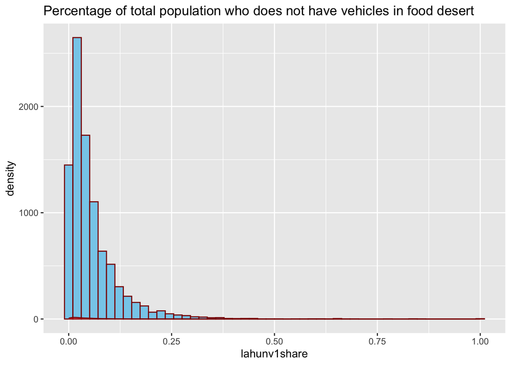

```r
data %>%
  filter(LILATracts_1And10 == 1) %>%
  ggplot(aes(x = lahunv1share)) +
  geom_histogram(bins = 50,fill = "skyblue", color="darkred") +
  geom_density(alpha = 0.5,fill= "red", color="darkred") +
  labs(title = "Percentage of total population who does not have vehicles in food desert")
```

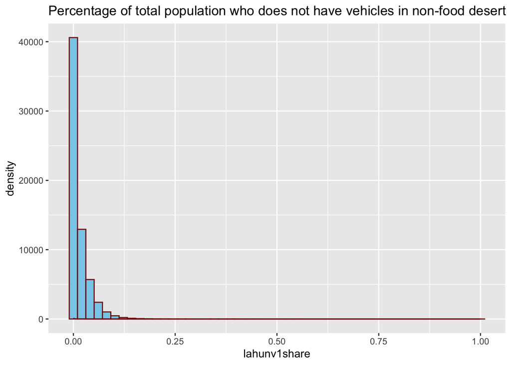

```r
data %>%
  filter(LILATracts_1And10 == 0) %>%
  ggplot(aes(x = lahunv1share)) +
  geom_histogram(bins = 50,fill = "skyblue", color="darkred") +
  geom_density(alpha = 0.5,fill= "red", color="darkred") +
  labs(title = "Percentage of total population who does not have vehicles in non-food desert")
```

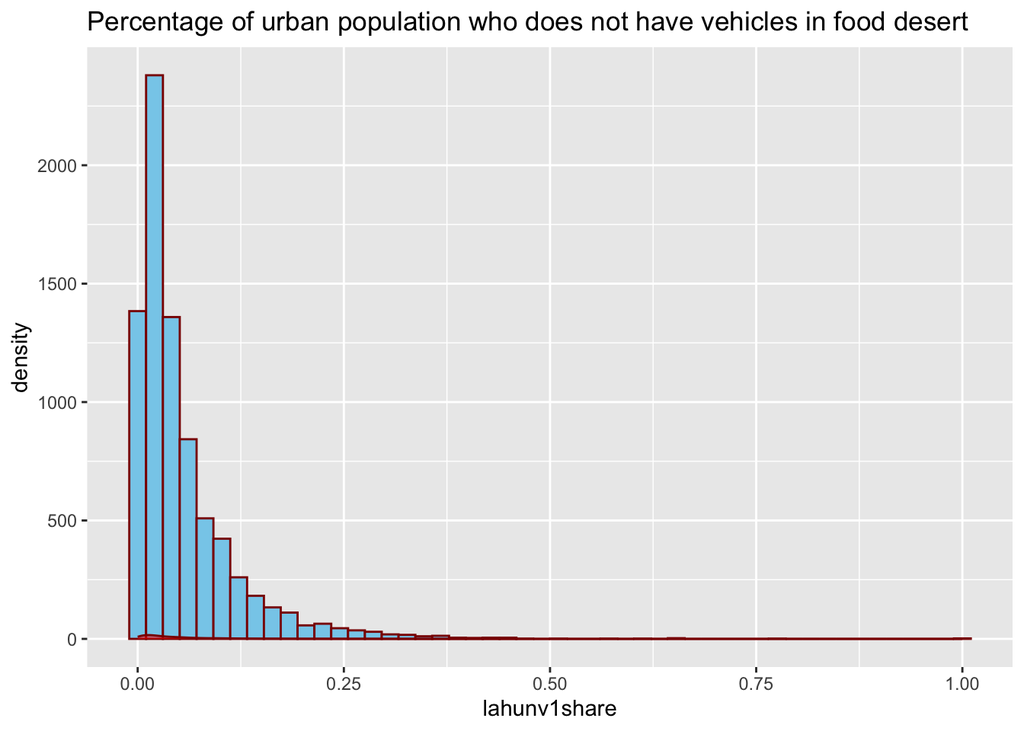

```r
data %>%
  filter(LILATracts_1And10 == 1 & Urban == 1) %>%
  ggplot(aes(x = lahunv1share)) +
  geom_histogram(bins = 50,fill = "skyblue", color="darkred") +
  geom_density(alpha = 0.5,fill = "red", color="darkred") +
  labs(title = "Percentage of urban population who does not have vehicles in food desert")
```

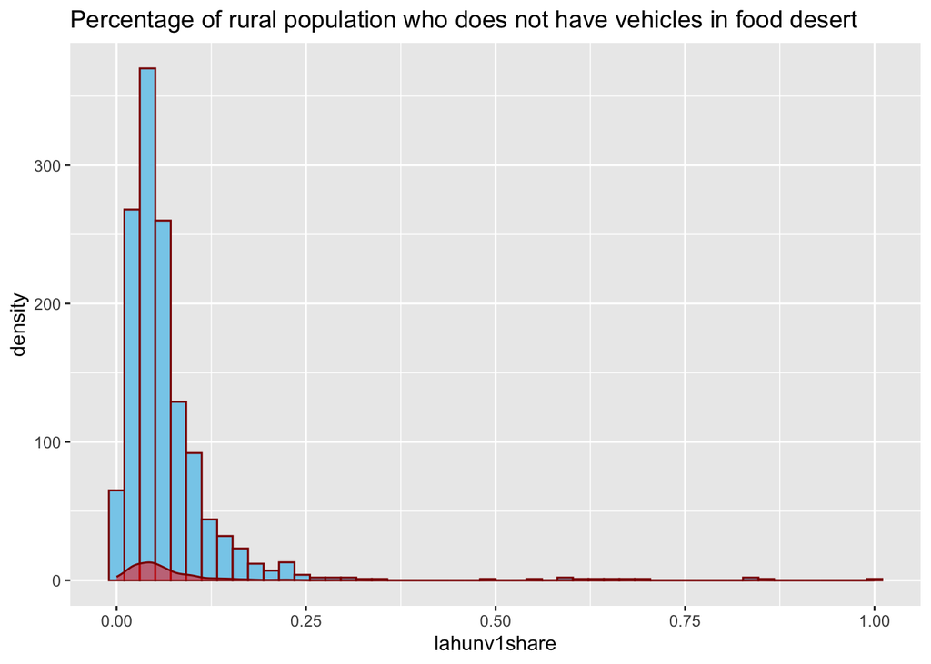

```r
data %>%
  filter(LILATracts_1And10 == 1 & Urban == 0) %>%
  ggplot(aes(x = lahunv1share)) +
  geom_histogram(bins = 50,fill = "skyblue", color="darkred") +
  geom_density(alpha = 0.5,fill = "red", color="darkred") +
  labs(title = "Percentage of rural population who does not have vehicles in food desert")
```

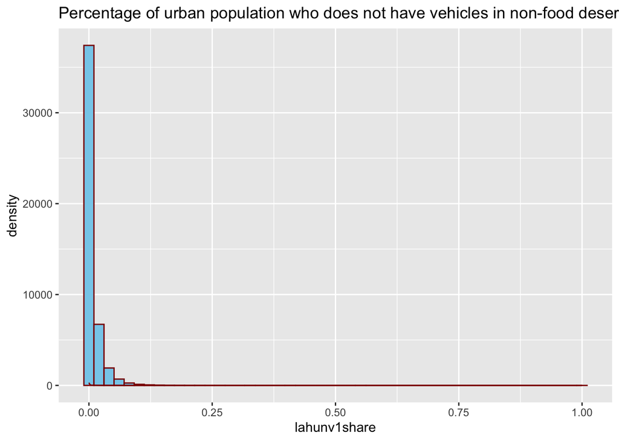

```r
data %>%
  filter(LILATracts_1And10 == 0 & Urban == 1) %>%
  ggplot(aes(x = lahunv1share)) +
  geom_histogram(bins = 50,fill = "skyblue", color="darkred") +
  geom_density(alpha = 0.5,fill = "red", color="darkred") +
  labs(title = "Percentage of urban population who does not have vehicles in non-food desert")
```

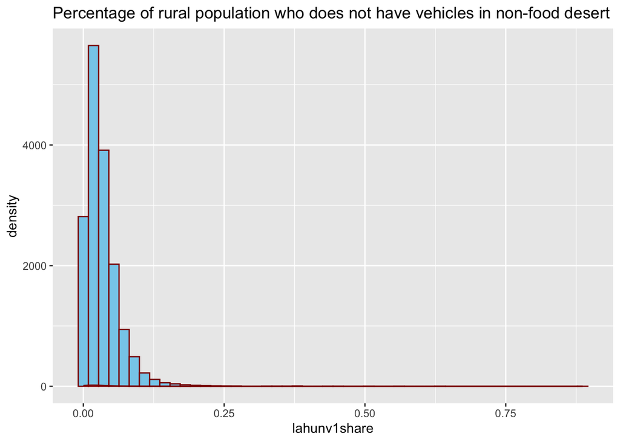

```r
data %>%
  filter(LILATracts_1And10 == 0 & Urban == 0) %>%
  ggplot(aes(x = lahunv1share)) +
  geom_histogram(bins = 50,fill = "skyblue", color="darkred") +
  geom_density(alpha = 0.5,fill = "red", color="darkred") +
  labs(title = "Percentage of rural population who does not have vehicles in non-food desert")
```

```r
# fd_urban <- data %>%
#   filter(LILATracts_1And10 == 1 & Urban == 1) %>%
#   summarise(per_without_vehicle_urban = mean(lahunv1share,na.rm = TRUE))
# print(fd_urban)
#
# fd_rural <- data %>%
#   filter(LILATracts_1And10 == 1 & Urban == 0) %>%
#    summarise(per_without_vehicle_rural = mean(lahunv10share,na.rm = TRUE))
# print(fd_rural)

# fd_vehicle <- data %>%
#   filter(LILATracts_1And10 == 1) %>%
#    summarise(per_with_vehicle = mean(lahunv10share,na.rm = TRUE))
# print(fd_vehicle)

result <- data %>%
  filter(LILATracts_1And10 == 1) %>%
  group_by(Urban) %>%
  summarise(
    lahunv1share_mean = mean(lahunv1share, na.rm = TRUE),
    lahunv10share_mean = mean(lahunv10share, na.rm = TRUE)
  )

print(result)
```

```
## # A tibble: 2 × 3
##   Urban lahunv1share_mean lahunv10share_mean
##   <int>             <dbl>              <dbl>
## 1     0            0.0668           0.0408
## 2     1            0.0546           0.000162
```

```r
fd_urban = subset(result, Urban == 1)["lahunv1share_mean"] * 100
fd_rural = subset(result, Urban == 0)["lahunv10share_mean"] * 100
fd_vehicle = 100 - fd_urban + fd_urban
```

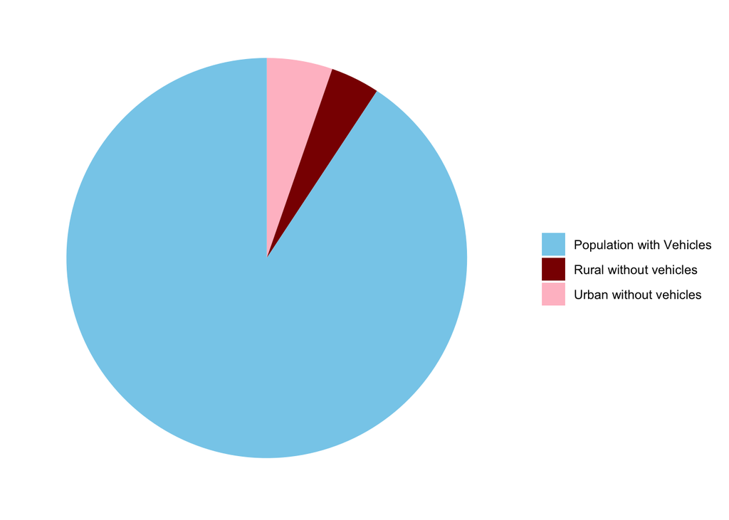

```r
#print(result[[2, "lahunv1share_mean"]])
#print(fd_urban)
data_pie <- data.frame(
  Category = c("Urban without vehicles", "Rural without vehicles", "Population with Vehicles"),
  Percentage = c(result[[2, "lahunv1share_mean"]] * 100 ,result[[1, "lahunv10share_mean"]] * 100, 100 - (result[[1, "lahunv1share_mean"]]  + result[[2, "lahunv10share_mean"]])* 100)
)
#print(data_pie)
# Generate the pie chart
ggplot(data_pie, aes(x = "", y = Percentage, fill = Category)) +
  geom_bar(stat = "identity", width = 1) +
  coord_polar("y", start=0) +
  theme_minimal() +
  theme(
    axis.text.x = element_blank(),
    axis.title.x = element_blank(),
    axis.title.y = element_blank(),
    panel.border = element_blank(),
    panel.grid=element_blank(),
    axis.ticks = element_blank(),
    plot.title=element_text(size=14, face="bold")
  ) +
  labs(fill = "") +
  scale_fill_manual(values = c("skyblue", "darkred", "pink"))
```

Around 5% urban population in food desert doesn’t have vehicles. Around 4% rural population in food desert doesn’t have vehicles. 91% population in food desert have vehicles.

### Share of population without vehicles - boxplots

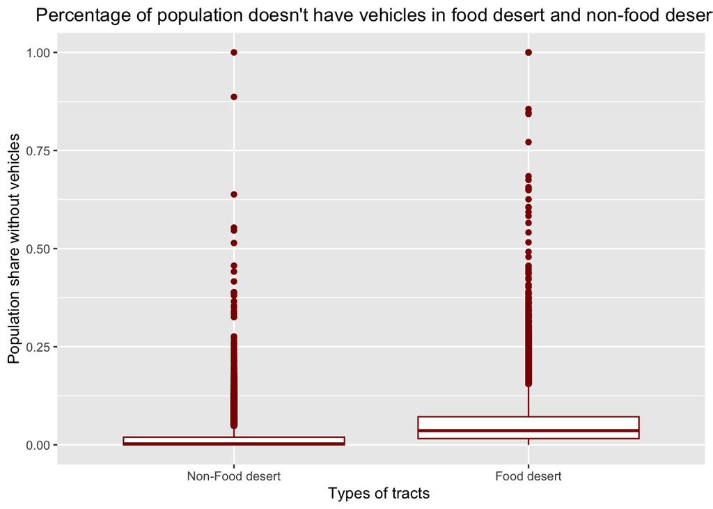

```r
data$LILATracts_1And10 <- as.factor(data$LILATracts_1And10)


levels(data$LILATracts_1And10) <- c("Non-Food desert", "Food desert")

ggplot(data = data,
       aes(x = LILATracts_1And10, y =lahunv1share)) +
      geom_boxplot(fill='white', color="darkred") +
      labs(title="Percentage of population doesn't have vehicles in food desert and non-food deserts",
      x ="Types of tracts ", y = "Population share without vehicles") +
      theme(plot.title = element_text(hjust = 0.5))
```

Seems like there is a lot of outliers in the data to make any conclusions. So removed outliers using KD2 method.

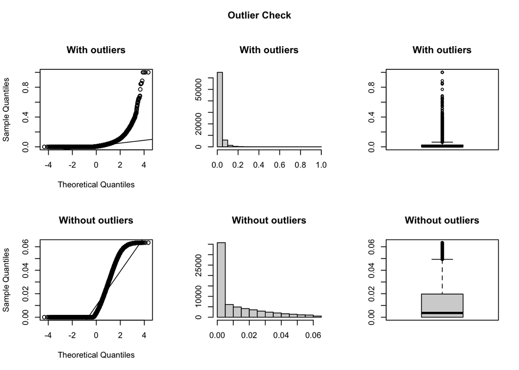

```
## Outliers identified: 5321
## Proportion (%) of outliers: 7.9
## Mean of the outliers: 0.11
## Mean without removing outliers: 0.02
## Mean if we remove outliers: 0.01
## Outliers successfully removed
```

```r
app_wo_gre_outlier <- ezids::outlierKD2(data, lahunv1share ,qqplt= TRUE, boxplt= TRUE, rm = TRUE)
```

```r
#str(app_wo_gre_outlier)
#gre_na = sum(is.na(app_wo_gre_outlier$gre))
```

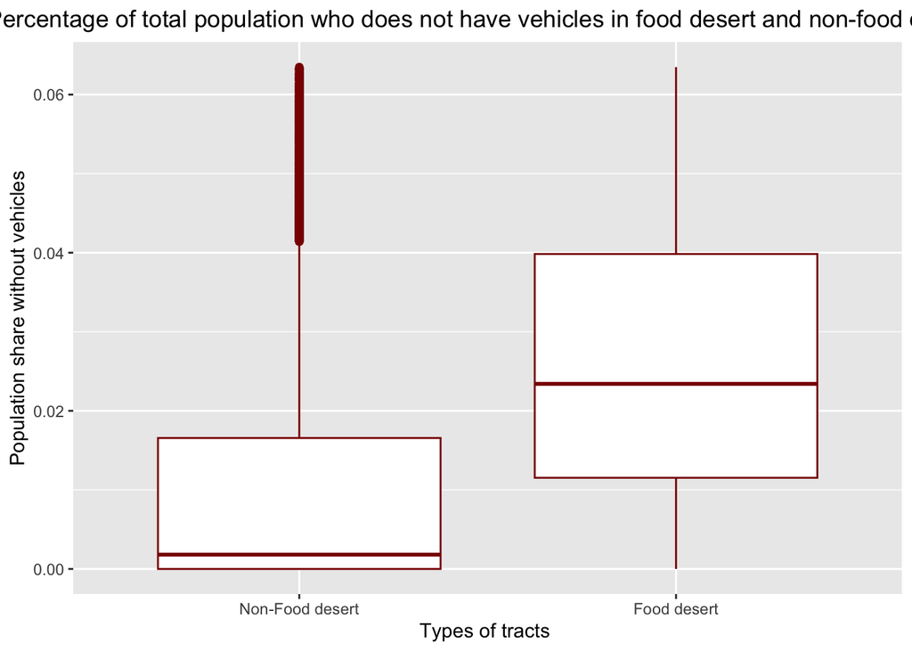

```r
app_wo_gre_outlier$LILATracts_1And10 <- as.factor(app_wo_gre_outlier$LILATracts_1And10)


levels(app_wo_gre_outlier$LILATracts_1And10) <- c("Non-Food desert", "Food desert")

ggplot(data = app_wo_gre_outlier,
       aes(x = LILATracts_1And10, y =lahunv1share)) +
      geom_boxplot(fill='white', color="darkred") +
      labs(title="Percentage of total population who does not have vehicles in food desert and non-food deserts",
      x ="Types of tracts ", y = "Population share without vehicles") +
      theme(plot.title = element_text(hjust = 0.5))
```

- A higher percentage of the population in food deserts lack vehicles compared to those in non-food desert.
- This could be concerning, as people in food deserts without vehicles may have even more difficulty accessing fresh and healthy food.

#### Observations from the box plot

Central Tendency: The median line inside the box for the “food desert” category appears to be higher than the “non-food desert” category. This suggests that, on average, a higher percentage of the population in food deserts lack vehicles compared to those in non-food deserts.

Spread & Variability: The interquartile range is higher for food desert.

Skewness: The median line appears to be roughly in the middle of the box for food desert suggesting that the distribution of the share of the population without vehicles in food desert is roughly symmetric, but non-food desert is skewed towards the right.

Overall Comparison: The entire box (representing the middle 50% of the data) for the “food desert” category is higher on the y-axis compared to the “non-food desert” category. This indicates that a larger share of the population in food deserts typically lacks vehicles compared to those in non-food deserts. This could be concerning, as people in food deserts without vehicles may have even more difficulty accessing fresh and healthy food.

### Vehicle access in rural and urban tracts

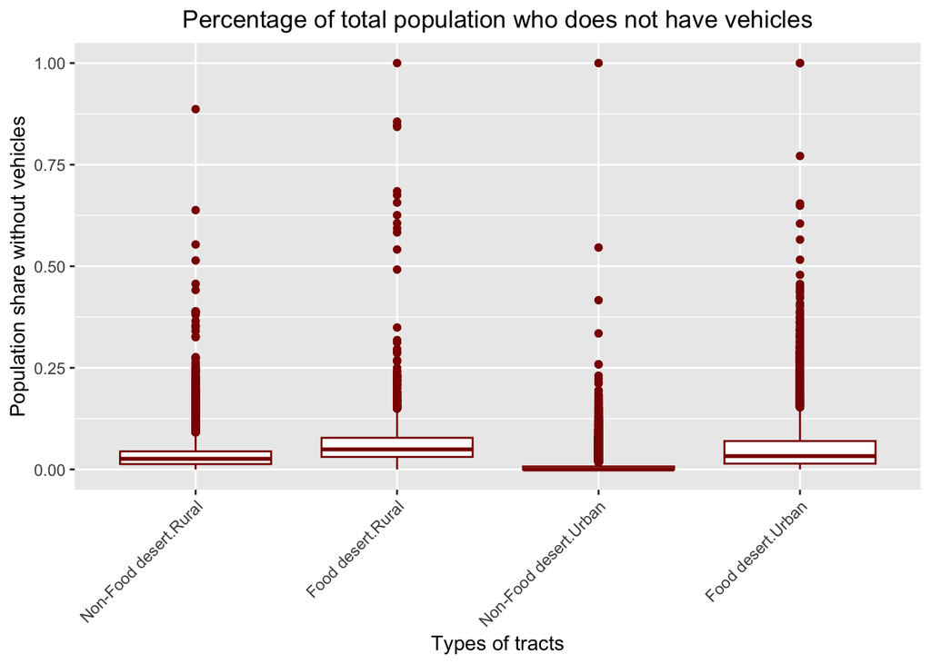

```r
data$Urban <- as.factor(data$Urban)
levels(data$Urban) <- c("Rural", "Urban")
ggplot(data = data,
       aes(x = interaction(LILATracts_1And10, Urban), y = lahunv1share)) +
  geom_boxplot(fill='white', color="darkred") +
  labs(title="Percentage of total population who does not have vehicles",
       x ="Types of tracts", y = "Population share without vehicles") +
  theme(plot.title = element_text(hjust = 0.5),
        axis.text.x = element_text(angle = 45, hjust = 1))
```

Seems like there is a lot of outliers in the data to make any conclusions. So let’s use outlier removed data.

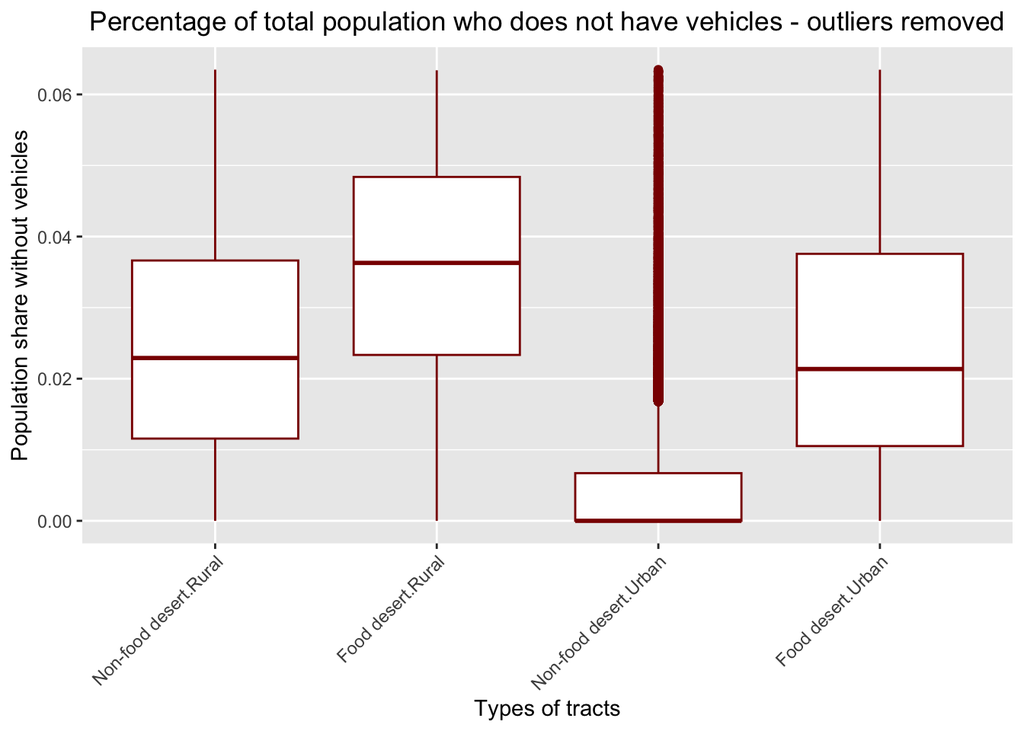

```r
app_wo_gre_outlier$Urban <- as.factor(app_wo_gre_outlier$Urban)
levels(app_wo_gre_outlier$Urban) <- c("Rural", "Urban")

app_wo_gre_outlier$LILATracts_1And10 <- as.factor(app_wo_gre_outlier$LILATracts_1And10)
levels(app_wo_gre_outlier$LILATracts_1And10) <- c("Non-food desert", "Food desert")
ggplot(data = app_wo_gre_outlier,
       aes(x = interaction(LILATracts_1And10, Urban), y = lahunv1share)) +
  geom_boxplot(fill='white', color="darkred") +
  labs(title="Percentage of total population who does not have vehicles - outliers removed",
       x ="Types of tracts", y = "Population share without vehicles") +
  theme(plot.title = element_text(hjust = 0.5),
        axis.text.x = element_text(angle = 45, hjust = 1))
```

#### Non-Food Desert in Urban (3rd category):

- Central Tendency: The median suggests that a relatively low percentage of the population in non-food desert urban areas lack vehicle access, even lower than the non-food desert rural areas.

#### Urban Areas:

The non-food desert urban areas have the smallest median percentage of people without vehicle access. This is likely because urban areas often have alternative modes of transportation, such as public transit, walking, or biking, making vehicle ownership less necessary. Moreover, urban areas often have amenities and services within walking distance, further reducing the need for a vehicle.

#### Impact of Food Deserts:

In both rural and urban contexts, food deserts show a higher median percentage of people without vehicle access compared to non-food deserts. This is a significant concern because it suggests that people in food deserts, who already might have limited access to healthy food options, might also face transportation challenges.

#### Rural vs. Urban:

While non-food desert urban areas have the lowest median percentage of people without vehicle access, food desert rural areas have the highest. This highlights the impact of food desert status on transportation barriers, irrespective of the urban or rural context.

# Question 6: Income-related Variables and Food Deserts

## Visualizing Median Family Income

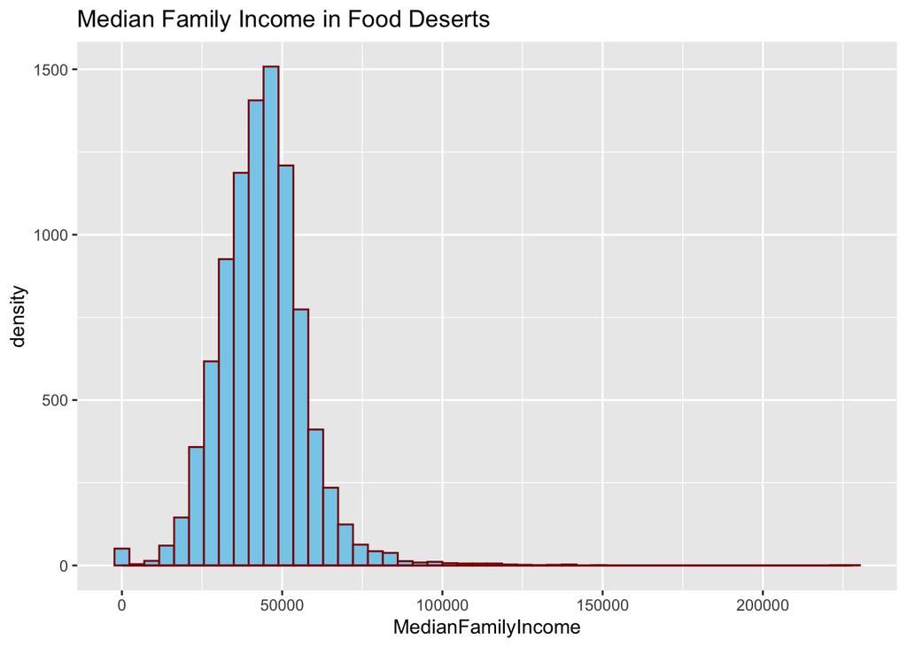

```r
data %>%
  filter(LILATracts_1And10 == "Food desert") %>%
  ggplot(aes(x = MedianFamilyIncome)) +
  geom_histogram(bins = 50, fill='skyblue', color="darkred") +  # Changed colors here
  geom_density(alpha = 0.8, fill="red", color="darkred") +      # And here
  labs(title = "Median Family Income in Food Deserts")
```

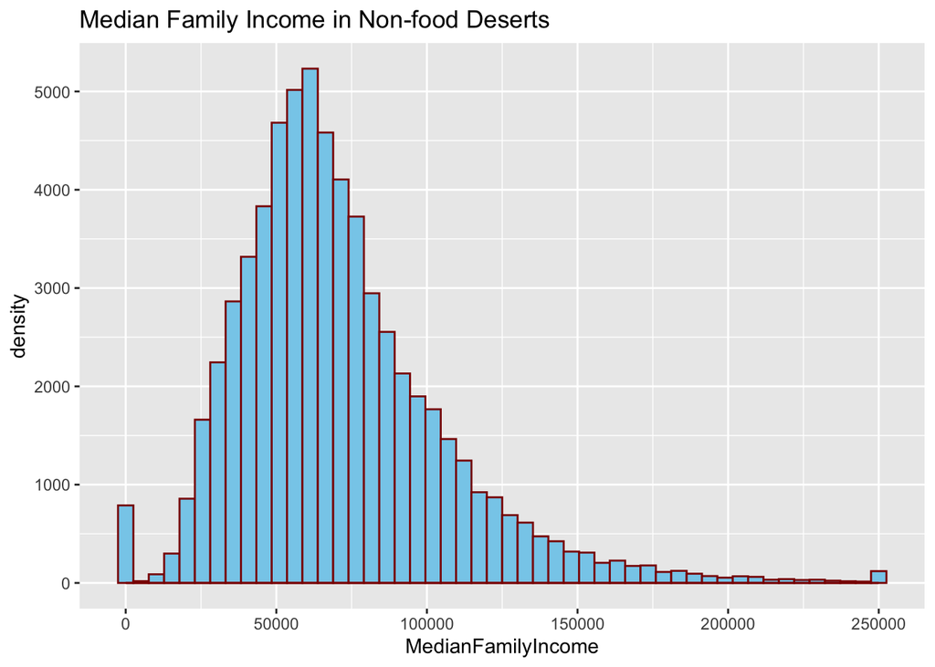

```r
data %>%
  filter(LILATracts_1And10 == "Non-Food desert") %>%
  ggplot(aes(x = MedianFamilyIncome)) +
  geom_histogram(bins = 50, fill='skyblue', color="darkred") +  # Changed colors here
  geom_density(alpha = 0.5, fill = "red", color="darkred") +      # And here
  labs(title = "Median Family Income in Non-food Deserts")
```

### Median income in food desert - boxplots

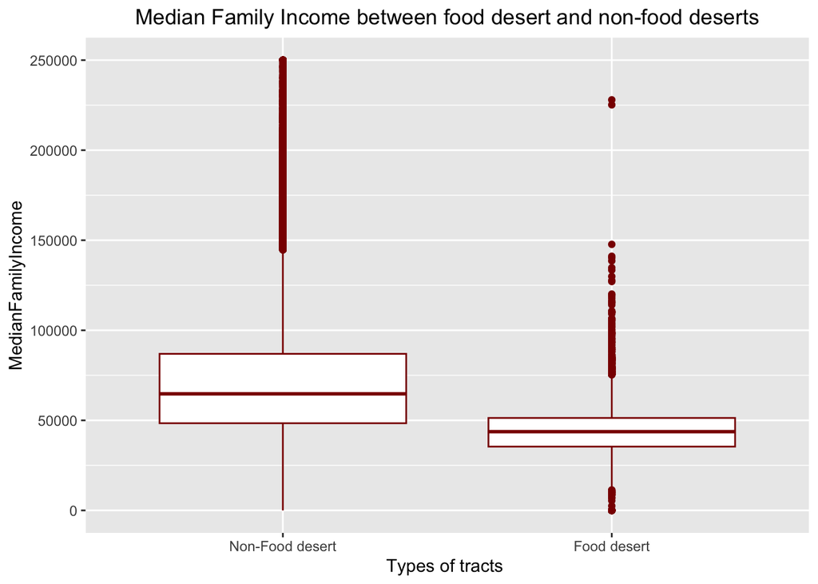

```r
data$LILATracts_1And10 <- as.factor(data$LILATracts_1And10)


levels(data$LILATracts_1And10) <- c("Non-Food desert", "Food desert")

ggplot(data = data,
       aes(x = LILATracts_1And10, y = MedianFamilyIncome)) +
      geom_boxplot(fill='white', color="darkred") +
      labs(title="Median Family Income between food desert and non-food deserts",
      x ="Types of tracts ", y = "MedianFamilyIncome") +
      theme(plot.title = element_text(hjust = 0.5))
```

## Confidence Interval tests

```r
fd_data <- subset(data, data$LILATracts_1And10 == "Food desert")

non_fd_data <- subset(data, data$LILATracts_1And10 == "Non-Food desert")
#print(fd_data)
ttest_fd_medincome_95 = t.test(x=fd_data$MedianFamilyIncome, conf.level=0.95 )
ttest_non_fd_medincome_95 = t.test(x=non_fd_data$MedianFamilyIncome, conf.level=0.95 )

print(ttest_fd_medincome_95)
```

```
##
##  One Sample t-test
##
## data:  fd_data$MedianFamilyIncome
## t = 307, df = 9244, p-value <2e-16
## alternative hypothesis: true mean is not equal to 0
## 95 percent confidence interval:
##  43566 44127
## sample estimates:
## mean of x
##     43847
```

```r
print(ttest_non_fd_medincome_95)
```

```
##
##  One Sample t-test
##
## data:  non_fd_data$MedianFamilyIncome
## t = 514, df = 63618, p-value <2e-16
## alternative hypothesis: true mean is not equal to 0
## 95 percent confidence interval:
##  70589 71129
## sample estimates:
## mean of x
##     70859
```

#### Food deserts

The T-intervals for the median income

- **At 0.95 level**

  [4.35663^{4}, 4.41271^{4}]

#### Non-Food deserts

The T-intervals for the median income in non-food desert

- **At 0.95 level**

  [7.05887^{4}, 7.11295^{4}]

The difference in the intervals indicates the median income between food desert and non-food desert is different.

## ANOVA ON median income

Null hypothesis : There is no difference in the median income between food desert and non-food desert Alternate hypothesis : There is difference in the median income between food desert and non-food desert

```r
med_income_aov = aov(MedianFamilyIncome ~ LILATracts_1And10, data = data)
# plant_aov  # this does not give the easy-to-read result of the aov analysis
# summary(plant_aov)
plantaovsummary = summary(med_income_aov)
plantaovsummary
```

```
##                      Df   Sum Sq  Mean Sq F value Pr(>F)
## LILATracts_1And10     1 5.89e+12 5.89e+12    5448 <2e-16 ***
## Residuals         72862 7.88e+13 1.08e+09
## ---
## Signif. codes:  0 '***' 0.001 '**' 0.01 '*' 0.05 '.' 0.1 ' ' 1
```

At level of significance alpha set at = 0.05, as The p-value 2e-16 is less than the 0.05, we reject the null hypothesis “There is no difference in the median income between food desert and non-food desert” Given the large F value and the extremely low p-value, we can be confident in this result.

The anova results tell us that there is statistically significant difference in median income among food desert and non -deserts.

### Post-hoc Tukey HSD

```r
tukeyAoV <- TukeyHSD(med_income_aov)
tukeyAoV
```

```
##   Tukey multiple comparisons of means
##     95% family-wise confidence level
##
## Fit: aov(formula = MedianFamilyIncome ~ LILATracts_1And10, data = data)
##
## $LILATracts_1And10
##                               diff    lwr    upr p adj
## Food desert-Non-Food desert -27012 -27730 -26295     0
```

The post-hoc test confirms that families living in food deserts have a significantly lower median income compared to those not living in food deserts.

#### Median Family Income in urban and rural areas

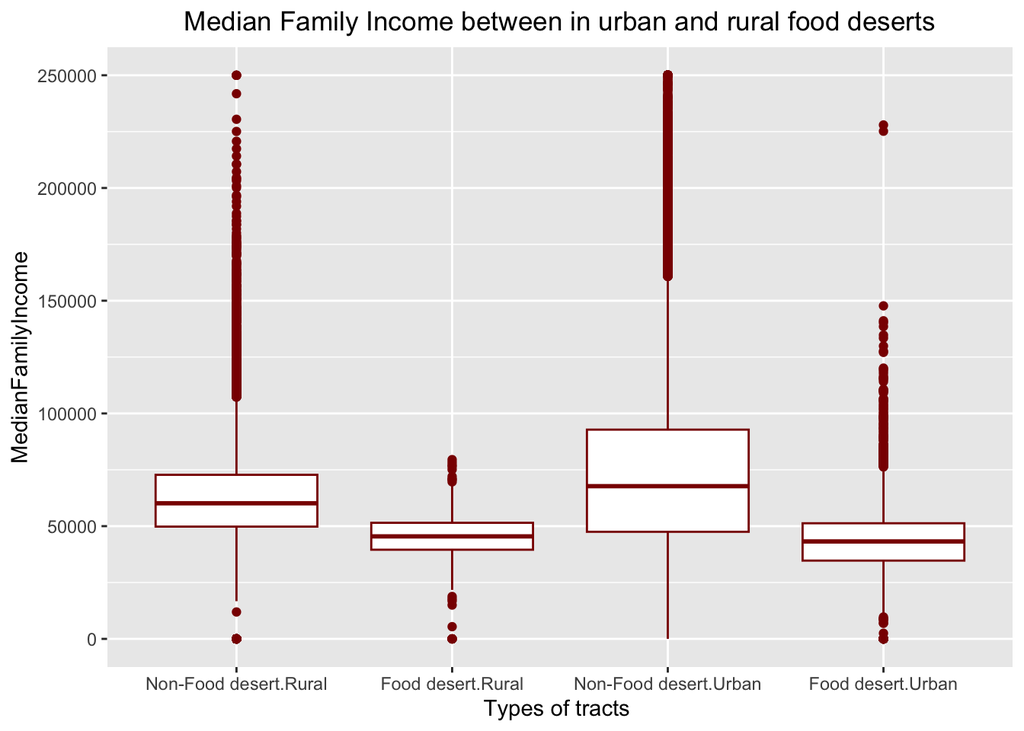

```r
data$LILATracts_1And10 <- as.factor(data$LILATracts_1And10)
levels(data$LILATracts_1And10) <- c("Non-Food desert", "Food desert")

data$Urban <- as.factor(data$Urban)
levels(data$Urban) <- c("Rural", "Urban")
ggplot(data = data,
       aes(x = interaction(LILATracts_1And10, Urban), y = MedianFamilyIncome)) +
      geom_boxplot(fill='white', color="darkred") +
      labs(title="Median Family Income between in urban and rural food deserts",
      x ="Types of tracts ", y = "MedianFamilyIncome") +
      theme(plot.title = element_text(hjust = 0.5))
```

**Urban**: As expected Non-food deserts in urban have higher median income than others.

**Rural**:Contrary to common perceptions, rural food deserts appear to have median family income similar to the urab food deserts.This suggest that the food desert in the rural areas is not solely due to economic reasons but could be influenced by other factors like distribution logistics, infrastructure, or availability of food retailers.